# Homework 3

## 3.18 Heights of female college students.

Below are heights of 25 female college students. 54,55,56,56,57,58,58,59,60,60,60,61,61,62,62,63,63,63,64,65,65,67,67,69,73 (a) The mean height is 61.52 inches with a standard deviation of 4.58 inches. Use this information to determine if the heights approximately follow the 68-95-99.7% Rule.

#### (a) The mean height is 61.52 inches with a standard deviation of 4.58 inches. Use this information to determine if the heights approximately follow the 68-95-99.7% Rule.

The data set approximately follow the 68-95-99.7% rule.

Findings based on calculations below:

68% fall within 1 standard deviation 96% fall within 2 standard deviations 100% fall within 3 standard deviations

#### Heigth Mean

```r
heights <- c(54, 55, 56, 56, 57, 58, 58, 59, 60, 60, 60, 61, 61,
             62, 62, 63, 63, 63, 64, 65, 65, 67, 67, 69, 73)
mean_height <- mean(heights)
mean_height
```

```
## [1] 61.52
```

#### Heigth SD

```r
sd_height <- sd(heights)
sd_height
```

```
## [1] 4.583667
```

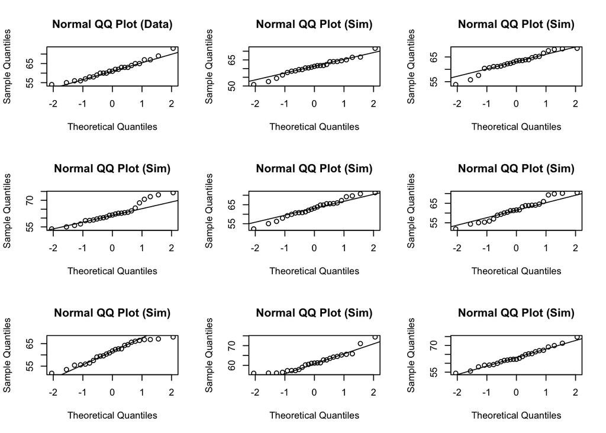

```r
qqnormsim(heights)
```

```r
within.1sd <- heights[which(heights < mean_height + sd_height & heights > mean_height - sd_height)]
within.2sd <- heights[which(heights < mean_height + 2*sd_height & heights > mean_height - 2*sd_height)]
within.3sd <- heights[which(heights < mean_height + 3*sd_height & heights > mean_height - 3*sd_height)]
print (paste0("1sd range : ",length(within.1sd)/length(heights)))
```

```
## [1] "1sd range : 0.68"
```

```r
print (paste0("2sd range : ",length(within.2sd)/length(heights)))
```

```
## [1] "2sd range : 0.96"
```

```r
print (paste0("3sd range : ",length(within.3sd)/length(heights)))
```

```
## [1] "3sd range : 1"
```

## 3.22 Defective rate.

#### A machine that produces a special type of transistor (a component of computers) has a 2% defective rate. The production is considered a random process where each transistor is independent of the others.

#### Probability of success (p) is .02 –> defective transistor #### Probability of failure is .98 –> not defective transistor

### (a) What is the probability that the 10th transistor produced is the first with a defect?

The probability that the 10th transistor is the first with a defect is 1.67%

```r
print (paste0("probability that the 10th transistor: " , (1-.02)^9 * .02 ))
```

```
## [1] "probability that the 10th transistor: 0.016674955242603"
```

### (b) What is the probability that the machine produces no defective transistors in a batch of 100?

```r
print (paste0("The probability that there are no defective transistors in a batch of 100 is : ", (1-.02)^100))
```

```
## [1] "The probability that there are no defective transistors in a batch of 100 is : 0.132619555894753"
```

### (c) On average, how many transistors would you expect to be produced before the first with a defect? What is the standard deviation?

#### The standard deviation is 49.50

```r
print (paste0("Mean : ", 1/0.2))
```

```
## [1] "Mean : 5"
```

```r
print (paste0("SD : ", sqrt((1-.02)/(.02^2))))
```

```
## [1] "SD : 49.4974746830583"
```

### (d) Another machine that also produces transistors has a 5% defective rate where each transistor is produced independent of the others. On average how many transistors would you expect to be produced with this machine before the first with a defect? What is the standard deviation?

Probability of success (p) is .05 –> defective transisitor Probability of failure is .95 –> not defective transistor We would expect to see 20 nondefective transistors before seeing the first defective one.

```r
print (paste0("Mean : ", 1/.05))
```

```
## [1] "Mean : 20"
```

The standard deviation is 19.49359.

```r
print (paste0("SD : ", sqrt((1-.05)/(.05^2))))
```

```
## [1] "SD : 19.4935886896179"
```

## 3.38 Male children.

While it is often assumed that the probabilities of having a boy or a girl are the same, the actual probability of having a boy is slightly higher at 0.51. Suppose a couple plans to have 3 kids.

### (a) Use the binomial model to calculate the probability that two of them will be boys.

- success = having a boy
- probability of success, p = 0.51
- n = 3
- k = 2 #### The probablity of having 2 boys in 3 children: 38.23%

```r
choose(3,2) * (0.51)^2 * (1 - 0.51) #0.382347
```

```
## [1] 0.382347
```

### (b) Write out all possible orderings of 3 children, 2 of whom are boys. Use these scenarios to calculate the same probability from part (a) but using the addition rule for disjoint outcomes. Confirm that your answers from parts (a) and (b) match.

```r
p1 <- (0.51) * (0.51) * (1 - .51)
print (paste0("P(Boy, Boy, Girl): ", p1))
```

```
## [1] "P(Boy, Boy, Girl): 0.127449"
```

```r
p2 <- (0.51) * (1 - 0.51) * (0.51)
print (paste0("P(Boy, Girl, Boy) : ", p2))
```

```
## [1] "P(Boy, Girl, Boy) : 0.127449"
```

```r
p3 <- (1 - 0.51) * (0.51) * (0.51)
print (paste0("P(Girl, Boy, Boy): ", p3))
```

```
## [1] "P(Girl, Boy, Boy): 0.127449"
```

```r
print (paste0("Total_probility: ", p1+p2+p3))
```

```
## [1] "Total_probility: 0.382347"
```

```r
print ("(a) and (b) results matched ")
```

```
## [1] "(a) and (b) results matched "
```

### (c) If we wanted to calculate the probability that a couple who plans to have 8 kids will have 3 boys, briefly describe why the approach from part (b) would be more tedious than the approach from part (a).

##### Answer: Part B would be more tedicious because you would have to write out 8 different equations with 8 different probabilities.

## 3.42 Serving in volleyball.

### A not-so-skilled volleyball player has a 15% chance of making the serve, which involves hitting the ball so it passes over the net on a trajectory such that it will land in the opposing team’s court. Suppose that her serves are independent of each other.

*###* p = .15 (success = make a successful serve) ### (a) What is the probability that on the 10th try she will make her 3rd successful serve?

```r
p <-  choose(9,2) * (.15)^2 * (1 - .15)^(9-2) * (.15)
print (paste0("The probability that on the 10th try she will make her 3rd successful serve: ", p))
```

```
## [1] "The probability that on the 10th try she will make her 3rd successful serve: 0.0389501162261719"
```

### b) Suppose she has made two successful serves in nine attempts. What is the probability that her 10th serve will be successful?

#### Answer: Each event is independent of one another, the probability of her 10th serve being successful is 15%

### (c) Even though parts (a) and (b) discuss the same scenario, the probabilities you calculated should be different. Can you explain the reason for this discrepancy?

#### It is because that part a was looking for a specific combination of successes with serving. and part b was only concerned with one serve.